# Time & Space Prediction: The case of Philly Bike Share

### 3.2 ridershare trips count by week

We plotted the ridershare trips by week. These plots indicate that except for the holiday effect, ridershare trips variation by week is not much different.Besides, the consistent peaks and troughs suggest a definite time trends that reaffirm our time lag feature engineering approach.

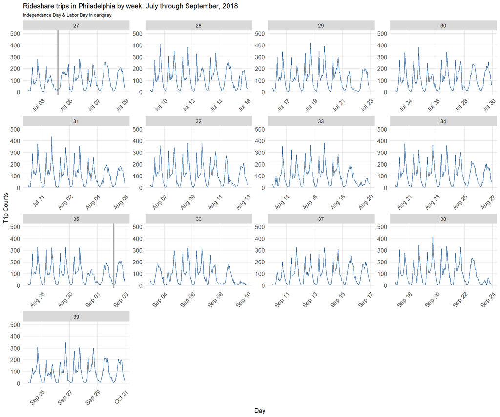

```r
as.data.frame(ride.panel) %>%
  group_by(week, interval60) %>%
  summarize(Trip_Count = sum(Trip_Count)) %>%
  ggplot(aes(interval60,Trip_Count)) +
  geom_line(color="#336699") +
  plotTheme() +
  facet_wrap(~week, scales="free", ncol=4) +
  ylim(0,500) +
  geom_vline(xintercept = as.POSIXct("2018-07-04 00:00:00 UTC"), color = "darkgray", size=1.1) +
  geom_vline(xintercept = as.POSIXct("2018-09-02 00:00:00 UTC"), color = "darkgray", size=1.1)+
  labs(title="Rideshare trips in Philadelphia by week: July through September, 2018",
       subtitle="Independence Day & Labor Day in darkgray", x="Day", y="Trip Counts")
```

### 3.3 ridershare trips count by day of the week

Then, we plot the ridershare trips cout by day of the week, it is clearly that there exists a significant difference in the count of ridershare trips between weekdays and weekends. Also, the count of rideshare trips increased sharply during the morning and evening peak of weekdays.

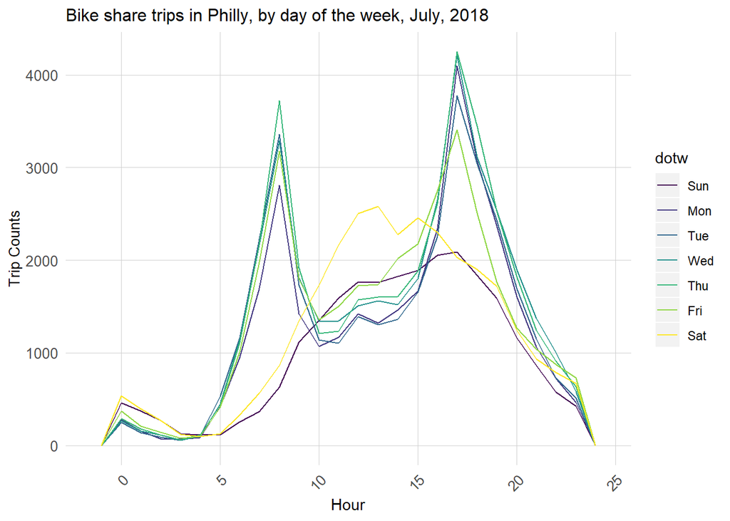

```r
ggplot(dat_tracts %>% mutate(hour = hour(start_time)))+
  geom_freqpoly(aes(hour, color = dotw), binwidth = 1)+
  labs(title="Bike share trips in Philly, by day of the week, July, 2018",
       x="Hour",
       y="Trip Counts")+
  plotTheme()
```

### 3.4 ridershare trip count as a function of time lags

Ridershare trip count as a function of the various time lags were visualized below. The correlation decreases with each additional hour, however, the predictive power returns with the 24 hour lag.These effects are very strong, which means that time effects most certainly play a vital role in forecasting ride share.

```r
plotData.lag <-
  as.data.frame(ride.panel) %>%
  filter(week == 30) %>%
  group_by(interval60) %>%
  summarise_at(vars(starts_with("lag"), "Trip_Count"), mean, na.rm = TRUE) %>%
  gather(Variable, Value, -interval60, -Trip_Count) %>%
  mutate(Variable = factor(Variable, levels=c("lagHour","lag2Hours","lag3Hours","lag4Hours",
                                              "lag12Hours","lag1day")))
correlation.lag <-
  plotData.lag %>%
  group_by(Variable) %>%
  summarize(correlation = round(cor(Value, Trip_Count),2))
```

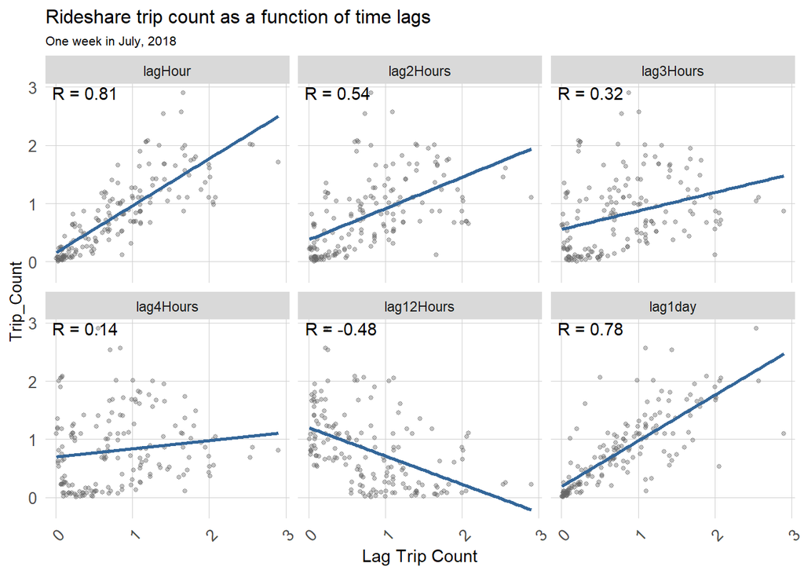

```r
plotData.lag %>%
  ggplot(aes(Value, Trip_Count)) +
  geom_point(size=1, alpha = 0.4,color="#666666") + geom_smooth(method = "lm", se = F,color="#336699") +
  facet_wrap(~Variable) +
  geom_text(data=correlation.lag, aes(label=paste("R =", correlation)),colour = "black",
            x=-Inf, y=Inf, hjust=-0.1, vjust=1.2) +
  labs(title = "Rideshare trip count as a function of time lags",
       subtitle= "One week in July, 2018", x = "Lag Trip Count") +
  plotTheme()
```

### 3.5 ridershare trip count as a function of selected Census variables

Because of the space/time panel nature of the data, census data cannot be used in the forecast. Nevertheless, for the purpose of exploratory analysis, we still analyzed correlation between ridershare trip count by tract for one week as a function of 6 Census variables.The followint plots shows that the Mean_commute_time, Med_Inc, Percent_White and Total_Pop is positively related to the ridershare trip count, while the Percent_Taking_Public_Trans variable is negarively related to the ridershare trip count.

```r
plotData.census <-
  as.data.frame(ride.panel) %>%
  filter(week == 30) %>%
  group_by(Origin.Tract) %>%
  summarize(Trip_Count = sum(Trip_Count))  %>%
  left_join(census, by=c("Origin.Tract" = "GEOID")) %>%
  select(Trip_Count,Origin.Tract,Med_Inc,Total_Pop,Percent_White,Mean_Commute_Time,Percent_Taking_Public_Trans,Med_Age) %>%
  na.omit() %>%
  gather(Variable, Value, -Origin.Tract, -Trip_Count) %>%
  filter(Variable =="Med_Inc"| Variable == "Total_Pop"|Variable == "Percent_White"|
         Variable == "Mean_Commute_Time"|Variable == "Percent_Taking_Public_Trans"|Variable == "Med_Age")

correlation.census <-
  plotData.census %>%
  group_by(Variable) %>%
  summarize(correlation = round(cor(Value, log(Trip_Count)),2))
```

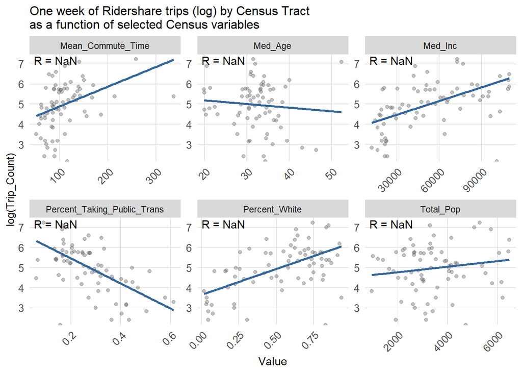

```r
ggplot(plotData.census, aes(Value,log(Trip_Count))) + geom_point(color="#666666",alpha = 0.4) + geom_smooth(method="lm", se = F,color='#336699') +
  facet_wrap(~Variable, scales="free", ncol=3) +
  geom_text(data=correlation.census, aes(label=paste("R =", correlation)),
            colour = "black", x=-Inf, y=Inf, hjust=-0.1, vjust=1.2) +
  plotTheme() +
  labs(title="One week of Ridershare trips (log) by Census Tract\nas a function of selected Census variables")
```

### 3.6 dose ridership vary when it??s raining or snowing?

Looking at week by group means in the resulting barplot does not neccessarily support the hypothesis that rain and snow increase the propensity to take rideshare.In most of the cases, ridership demand decreases during rainy/snowy days.

[figure not shown]

```r
as.data.frame(ride.panel) %>%
  group_by(interval60) %>%
  summarize(Trip_Count = sum(Trip_Count)) %>%
  left_join(weather.panel) %>%
  mutate(isPercip = ifelse(Precipitation > 0,"Rain/Snow", "None")) %>%
  group_by(week = week(interval60), isPercip) %>%
  summarize(Mean_Trip_Count = mean(Trip_Count)) %>%
  na.omit() %>%
  ggplot(aes(isPercip, Mean_Trip_Count)) +
  geom_bar(stat = "identity",fill="#336699") +
  facet_wrap(~week,ncol=6) +
  labs(title="Does ridership vary when it's raining or snowing?",
       subtitle="Mean trip count by week; July through August, 2018",
       x="Precipitation", y="Mean Trip Count") +
  plotTheme() + theme(axis.text.x = element_text(angle = 45, hjust = 1))
```

### 3.7 ridershare trips count per hour as a function of Temperature

Do more people take ride share when it??s colder? The trip count per hour as a function of temperature suggests the opposite - that ride share actually increases as temperatures warm.

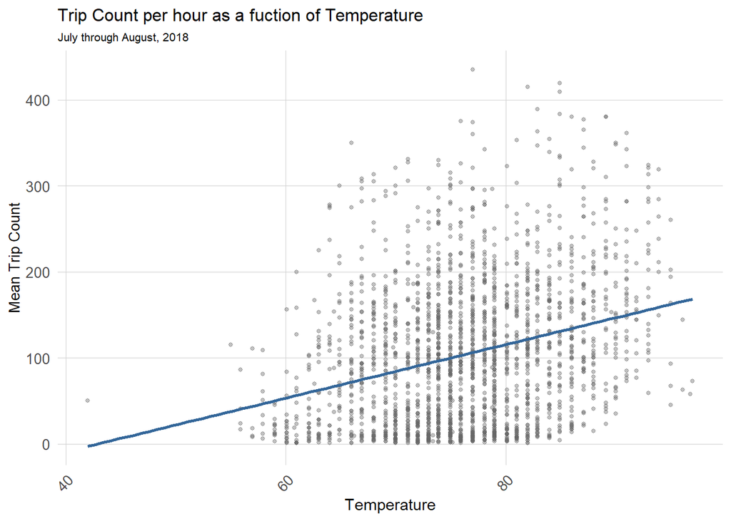

```r
as.data.frame(ride.panel) %>%
  group_by(interval60) %>%
  summarize(Trip_Count = sum(Trip_Count)) %>%
  left_join(weather.panel) %>%
  ggplot(aes(Temperature, Trip_Count)) +
  geom_point(size=1, color="#666666",alpha = 0.4) + geom_smooth(method = "lm", se= FALSE,color="#336699") +
  plotTheme() +
  labs(title="Trip Count per hour as a fuction of Temperature",
       subtitle="July through August, 2018",
       x="Temperature", y="Mean Trip Count")
```

### 3.8 ridershare trips count per hour by station

Through the maps of bike share trips per hour by station, we could find some interesting phenomena: ridershare trips are more frequent during the week than on weekends, and the ridershare trips count peaks during the PM rush in weekday.

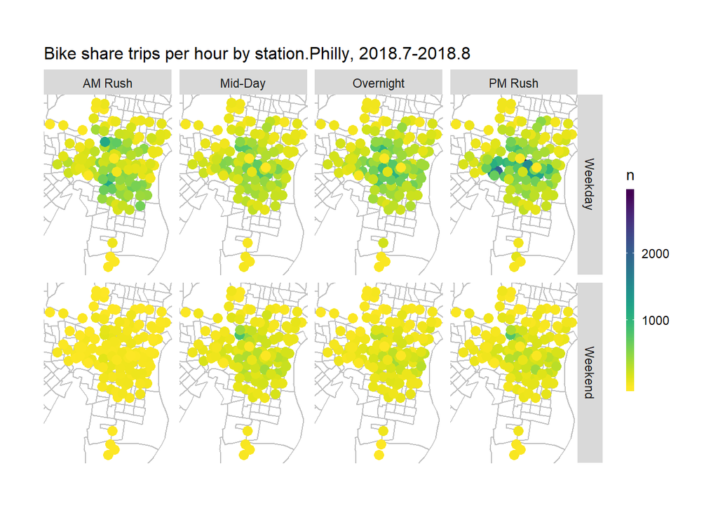

```r
ggplot()+
  geom_sf(data = tracts %>%
            st_transform(crs=4326),color = "grey", fill = "transparent")+
  geom_point(data = dat_tracts %>%
               mutate(hour = hour(start_time),
                      weekend = ifelse(dotw %in% c("Sun", "Sat"), "Weekend", "Weekday"),
                      time_of_day = case_when(hour(interval60) < 7 | hour(interval60) > 18 ~ "Overnight",
                                              hour(interval60) >= 7 & hour(interval60) < 10 ~ "AM Rush",
                                              hour(interval60) >= 10 & hour(interval60) < 15 ~ "Mid-Day",
                                              hour(interval60) >= 15 & hour(interval60) <= 18 ~ "PM Rush"))%>%
               group_by(start_station, start_lat, start_lon, weekend, time_of_day) %>%
               tally(),
             aes(x=start_lon, y = start_lat, color = n),
             fill = "transparent", alpha = 1, size = 3)+
  scale_colour_viridis(direction = -1,
                       discrete = FALSE, option = "D")+
  ylim(min(dat_tracts$start_lat), max(dat_tracts$start_lat))+
  xlim(min(dat_tracts$start_lon), max(dat_tracts$start_lon))+
  facet_grid(weekend ~ time_of_day)+
  labs(title="Bike share trips per hour by station.Philly, 2018.7-2018.8")+
  mapTheme()
```

### 3.9 sum of rideshare trips by tract and hour of the day

Then, we map the sum of rideshare trips by tract and hour of the day.These maps indicates us that trips are concentrated in the central city through 7 am to 8 pm. As the day goes on, trips decreases appear to eminate from the central city, outward.

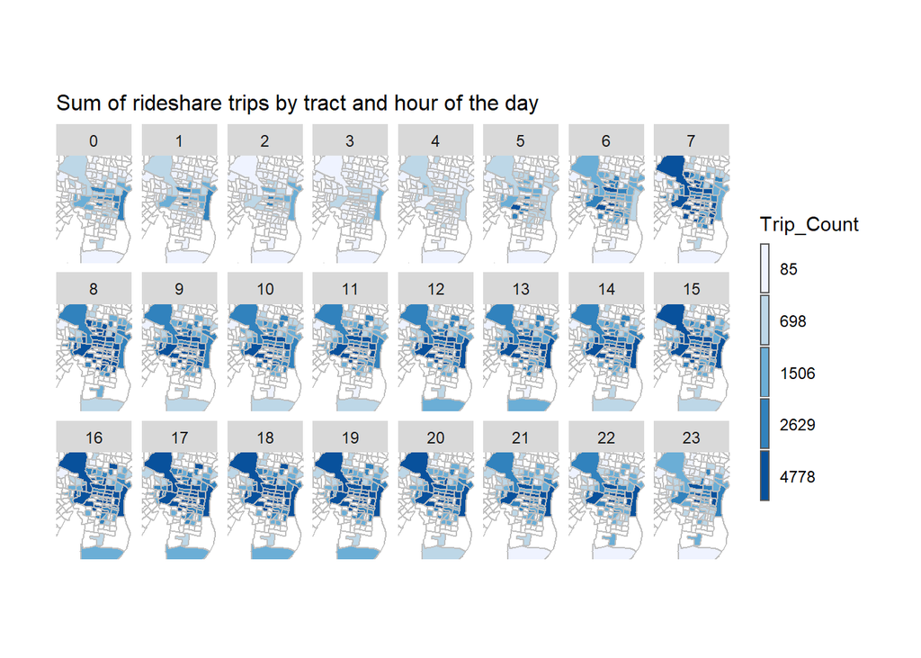

```r
spatial_dis <-
  left_join(ride.panel, tracts, by = c("Origin.Tract" = "GEOID")) %>%
  st_sf()

spatial_dis  %>%
  group_by(hour = hour(interval60), Origin.Tract) %>%
  summarize(Sum_Trip_Count = sum(Trip_Count)) %>%
  ggplot() + geom_sf(aes(fill = q5(Sum_Trip_Count))) +
  facet_wrap(~hour, ncol = 8) +
  scale_fill_manual(values = palette5,
                    labels = c("85", "698", "1506", "2629", "4778"),
                    name = "Trip_Count") +
  mapTheme()+
  ylim(min(dat_tracts$start_lat), max(dat_tracts$start_lat))+
  xlim(min(dat_tracts$start_lon), max(dat_tracts$start_lon))+
  labs(title="Sum of rideshare trips by tract and hour of the day") +
  geom_sf(data=tracts,color = "grey", fill = "transparent")
```

### 3.10 space/time animation

Below, we built an animated gif map of rideshare trips by tract and hour of the day. This gif confirms our views in section 3.9.

```r
week30 <- dat_tracts %>%
  filter(week == 30 & dotw == "Mon")

week30.panel <-
  expand.grid(
    interval60=unique(week30$interval60),
    Origin.Tract = unique(week30$Origin.Tract))

ride.animation.data <-
  week30 %>%
  mutate(Trip_Counter = 1) %>%
  right_join(week30.panel) %>%
  group_by(interval60, Origin.Tract) %>%
  summarize(Trip_Count = sum(Trip_Counter, na.rm=T)) %>%
  left_join(tracts,by=c("Origin.Tract" = "GEOID")) %>%
  st_sf() %>%
  mutate(Trips = case_when(Trip_Count == 0 ~ "0 trips",
                           Trip_Count > 0 & Trip_Count <= 3 ~ "1-3 trips",
                           Trip_Count > 3 & Trip_Count <= 6 ~ "4-6 trips",
                           Trip_Count > 6 & Trip_Count <= 10 ~ "7-10 trips",
                           Trip_Count > 10 ~ "10+ trips")) %>%
  mutate(Trips  = factor(Trips, levels=c("0 trips","1-3 trips","4-6 trips","7-10 trips","10+ trips")))
```

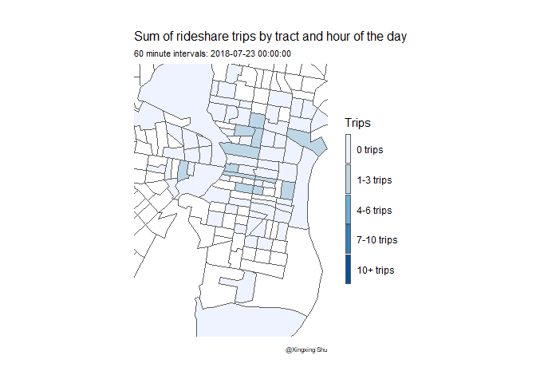

```r
rideshare_animation <-
  ggplot() +
  geom_sf(data=ride.animation.data, aes(fill=Trips)) +
  scale_fill_manual(values = palette5) +
  labs(title = "Rideshare pickups for one day in July 2018, Philly",
       subtitle = "60 minute intervals: {current_frame}", caption = "@Xingxing Shu") +
  transition_manual(interval60) +
  mapTheme()+
  ylim(min(dat_tracts$start_lat), max(dat_tracts$start_lat))+
  xlim(min(dat_tracts$start_lon), max(dat_tracts$start_lon))+
  labs(title="Sum of rideshare trips by tract and hour of the day") +
  geom_sf(data=tracts,fill = NA)

animate(rideshare_animation, duration=20)
```